# DATA 152 - FA25 - HW1

Caden Dirnberger

Due Sept 5, 2025 at 9:00pm in Canvas

**Instructions:** 1) Rename this file using your last name and first name. 2) Change “YOUR NAME HERE” in the preamble to your name. 3) Complete the following questions. Once you’re done, knit this file into an HTML and submit the HTML in Canvas.

Note: You may want to switch to Visual mode before beginning the assignment since it’s more readable than the source code version. Also, SAVE & KNIT YOUR WORK OFTEN.

## **QUESTION 1 [30]**

I want to learn about you! Please answer the following questions:

- **What year are you at Willamette (1st yr, 2nd yr, …)?**  
  2nd yr
- **What is your major?**  
  computer science and data science
- **What are your career goals? (No worries if you’re unsure. You can answer this as exactly or inexactly as you wish.)**  
  code video games or make my own video games.
- **Do you participate in any clubs, sports, volunteer orgs, etc at Willamette? If so, which ones?**  
  yes football
- **Tell me 3 interesting facts about you.**  
  I love to scuba Dive I love video games I love turtles

## **QUESTION 2 [10]**

Why are you taking this class? What are you most looking forward to in this class?

**ANSWER:** I am taking this class to learn more about data science. i am looking forward to coding with R

## **QUESTION 3 [10]**

Fill in the [when2meet form](https://tinyurl.com/data152-fa25-officehrs) to give me (Dr. Gore) an idea of when I should set my office hours. I realize some of you will are finalizing your course schedules in the first week and things may change, but this will give me a general idea of your availability. We can adjust as needed during the semester.

**ANSWER:** [nothing to fill in here, but I will be checking the poll results to see if you filled it out, so make sure you include your name when you do complete it.]

## **QUESTION 4 [50]**

It’s no secret that colleges in the US have been preparing for an “enrollment cliff” as a result of declining birthrates, political factors over the ROI of college, etc. Thus, enrollment is of peak interest. (For more information, check out this article from [Forbes](https://www.forbes.com/sites/davidrosowsky/2024/02/03/the-cliffs-of-higher-ed-whos-going-over-and-why/).)

Make sure the “us_district_enrollment_2016-2023.txt” file is in your working directory. (Not sure about your working directory? Run `getwd()` to find out where R is looking for the file.) Then complete the following problems to dig further into enrollment trends.

### 4A [5]

Uncomment the code below. Replace my working directory with your working directory in the `my_working_dir` variable. Then run the entire code block below to read in the dataset. Note: Make sure your working directory has a slash at the end of it.

```r
library(tidyverse)
 my_working_dir="C:/Users/caden/Data_152/Datasets/"
 the_file="us_district_enrollment_2016-2023.txt"
#
 full_path=paste(my_working_dir,the_file,sep="")
#
 ds=read_csv(full_path, col_types = 'cfddddddd')
```

### 4B [5]

Print the first 20 lines of the dataset using `head()`.

```r
head(ds)
```

```
## # A tibble: 6 × 9
##   District                   State Total Students All G…¹ Total Students All G…²
##   <chr>                      <fct>                  <dbl>                  <dbl>
## 1 21ST CENTURY CHARTER SCH … INDI…                   1337                   1329
## 2 21ST CENTURY CYBER CS      PENN…                   1239                   1536
## 3 21ST CENTURY PUBLIC ACADE… NEW …                    393                    364
## 4 A CENTER FOR CREATIVE EDU… ARIZ…                     NA                     NA
## 5 A E R O SPEC EDUC COOP     ILLI…                     NA                      0
## 6 A W BEATTIE CAREER CENTER  PENN…                      6                      6
## # ℹ abbreviated names: ¹`Total Students All Grades  2022-23`,
## #   ²`Total Students All Grades  2021-22`
## # ℹ 5 more variables: `Total Students All Grades  2020-21` <dbl>,
## #   `Total Students All Grades  2019-20` <dbl>,
## #   `Total Students All Grades  2018-19` <dbl>,
## #   `Total Students All Grades  2017-18` <dbl>,
## #   `Total Students All Grades  2016-17` <dbl>
```

### 4C [5]

Use `names()` to print the names of the columns in the dataset.

```r
names(ds)
```

```
## [1] "District"                           "State"
## [3] "Total Students All Grades  2022-23" "Total Students All Grades  2021-22"
## [5] "Total Students All Grades  2020-21" "Total Students All Grades  2019-20"
## [7] "Total Students All Grades  2018-19" "Total Students All Grades  2017-18"
## [9] "Total Students All Grades  2016-17"
```

### 4D [5]

Run `summary()` on the `ds` dataset.

```r
summary(ds)
```

```
##    District                State       Total Students All Grades  2022-23
##  Length:20536       CALIFORNIA: 2271   Min.   :     0
##  Class :character   TEXAS     : 1257   1st Qu.:   275
##  Mode  :character   OHIO      : 1150   Median :   713
##                     NEW YORK  : 1128   Mean   :  2695
##                     ILLINOIS  : 1069   3rd Qu.:  2023
##                     (Other)   :13655   Max.   :427795
##                     NA's      :    6   NA's   :2166
##  Total Students All Grades  2021-22 Total Students All Grades  2020-21
##  Min.   :     0.0                   Min.   :     0
##  1st Qu.:   255.5                   1st Qu.:   261
##  Median :   688.0                   Median :   700
##  Mean   :  2641.7                   Mean   :  2674
##  3rd Qu.:  1964.0                   3rd Qu.:  1998
##  Max.   :435958.0                   Max.   :460633
##  NA's   :1865                       NA's   :2115
##  Total Students All Grades  2019-20 Total Students All Grades  2018-19
##  Min.   :     0                     Min.   :     0
##  1st Qu.:   258                     1st Qu.:   267
##  Median :   701                     Median :   707
##  Mean   :  2731                     Mean   :  2755
##  3rd Qu.:  2031                     3rd Qu.:  2062
##  Max.   :483234                     Max.   :495255
##  NA's   :1988                       NA's   :2189
##  Total Students All Grades  2017-18 Total Students All Grades  2016-17
##  Min.   :     0                     Min.   :     0
##  1st Qu.:   277                     1st Qu.:   278
##  Median :   760                     Median :   765
##  Mean   :  2917                     Mean   :  2924
##  3rd Qu.:  2232                     3rd Qu.:  2238
##  Max.   :621414                     Max.   :633621
##  NA's   :3206                       NA's   :3268
```

### 4E [5]

Let’s customize the analysis. Filter `ds` to only include data for YOUR home state. (If your home state isn’t US-based, you may pick a random state.) Name this dataset `enroll`.

```r
enroll = ds %>% filter(State== "MONTANA")
```

### 4F [5]

How many rows and columns are in `enroll`?

```r
view(enroll)
ncol(enroll)
```

```
## [1] 9
```

```r
nrow(enroll)
```

```
## [1] 493
```

```r
# 9 columns and 493 rows
```

### 4G [5]

Which district had the highest enrollment in the 2022-2023 school year? Use `arrange` to answer this question.

```r
arrange(enroll,desc(`Total Students All Grades  2022-23`) )
```

```
## # A tibble: 493 × 9
##    District         State   Total Students All Grades  …¹ Total Students All G…²
##    <chr>            <fct>                           <dbl>                  <dbl>
##  1 BILLINGS ELEM    MONTANA                         10988                  11079
##  2 GREAT FALLS ELEM MONTANA                          7032                   7114
##  3 BILLINGS H S     MONTANA                          5610                   5660
##  4 MISSOULA ELEM    MONTANA                          5280                   5385
##  5 HELENA ELEM      MONTANA                          5225                   5181
##  6 BOZEMAN ELEM     MONTANA                          4651                   4711
##  7 MISSOULA H S     MONTANA                          3966                   3834
##  8 FLATHEAD H S     MONTANA                          3101                   3037
##  9 GREAT FALLS H S  MONTANA                          3095                   3130
## 10 KALISPELL ELEM   MONTANA                          3095                   3136
## # ℹ 483 more rows
## # ℹ abbreviated names: ¹`Total Students All Grades  2022-23`,
## #   ²`Total Students All Grades  2021-22`
## # ℹ 5 more variables: `Total Students All Grades  2020-21` <dbl>,
## #   `Total Students All Grades  2019-20` <dbl>,
## #   `Total Students All Grades  2018-19` <dbl>,
## #   `Total Students All Grades  2017-18` <dbl>, …
```

**ANSWER:** Billings ELEM

### 4H [5]

Uncomment and run the following code to reshape the `enroll` dataset.

```r
 enroll2=enroll %>%
    pivot_longer(
        cols=`Total Students All Grades  2022-23`:`Total Students All Grades  2016-17`,
        names_to="School_Year",
        values_to="Enrollment"
    ) %>%
    mutate(
        School_Year=str_replace_all(
            str_remove(School_Year,"Total Students All Grades  "),
            "-","-20")
    )

 head(enroll2,15)
```

```
## # A tibble: 15 × 4
##    District              State   School_Year Enrollment
##    <chr>                 <fct>   <chr>            <dbl>
##  1 ABSAROKEE ELEM        MONTANA 2022-2023          107
##  2 ABSAROKEE ELEM        MONTANA 2021-2022          112
##  3 ABSAROKEE ELEM        MONTANA 2020-2021          105
##  4 ABSAROKEE ELEM        MONTANA 2019-2020          127
##  5 ABSAROKEE ELEM        MONTANA 2018-2019          144
##  6 ABSAROKEE ELEM        MONTANA 2017-2018          150
##  7 ABSAROKEE ELEM        MONTANA 2016-2017          147
##  8 ABSAROKEE H S         MONTANA 2022-2023           71
##  9 ABSAROKEE H S         MONTANA 2021-2022           58
## 10 ABSAROKEE H S         MONTANA 2020-2021           74
## 11 ABSAROKEE H S         MONTANA 2019-2020           80
## 12 ABSAROKEE H S         MONTANA 2018-2019           86
## 13 ABSAROKEE H S         MONTANA 2017-2018           92
## 14 ABSAROKEE H S         MONTANA 2016-2017           85
## 15 ALBERTON K-12 SCHOOLS MONTANA 2022-2023          166
```

Using `enroll2`, create a summary table that shows the median district enrollment for each year represented in `enroll2`. Hint: `group_by`, `summarize`

```r
med_enroll = enroll2 %>% group_by(District, School_Year)  %>% summarize(Median_Enrollment = median(Enrollment, na.rm = TRUE))
```

### 4I [10]

Create a graph of your choosing that showcases enrollment trends in your home state over time. Make sure your graph is interpretable and clearly labeled.

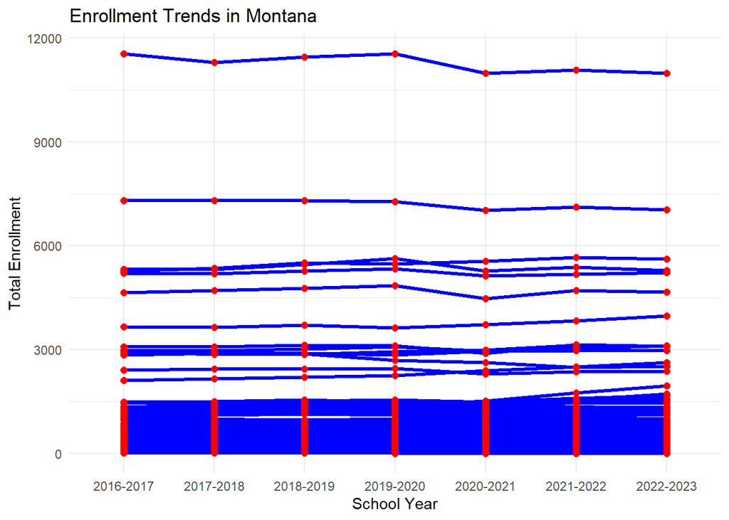

```r
med_enroll %>% ggplot(aes(x = School_Year, y = Median_Enrollment, group = District)) +
  geom_line(color = "blue", linewidth = 1.2) +
  geom_point(color = "red", size = 2) +
  labs(
    title = paste("Enrollment Trends in Montana"),
    x = "School Year",
    y = "Total Enrollment"
  ) +
  theme_minimal()
```

Congrats–You’re done with your first DATA 152 HW! Click the “Knit” button at the top of the window to create an HTML rendering of this document. Then submit BOTH the Rmd and HTML to Canvas.